# LASSO-Penalized Logistic Regression Sensitivity Analysis for Binary CRC Microbiome Classification

Harshini Chintala

2026-09-03

## 0.1 Notebook roadmap

**Purpose:** This notebook is one reproducible component of the CRC microbiome classification pipeline.

**Execution order** 1. Load the project environment and fixed random seed (`1910`). 2. Load only the validated project artifacts required for this analysis. 3. Perform the analysis exactly as documented below. 4. Generate tables/figures and save machine-readable outputs. 5. Record the session information used for the run.

**Output contract:** generated tables, figures, model objects, audit files, and session information are written under `02 Classical ML/results/`. The notebook itself renders to HTML with a floating table of contents, so the sections can be navigated from the left-hand panel in the knitted document.

**Reproducibility rule:** this repository preserves the validated analysis logic and project-wide seed. Environment restoration is handled by `renv.lock` for R and `requirements.txt` for Python. The notebooks do not silently install unpinned packages during knitting.

### 0.1.1 Reproducibility constants

- Project seed: **1910**
- Discovery cohort: **ZellerG_2014**
- Primary task: **Healthy vs CRC; adenoma excluded**
- Frozen discovery split: **92 training / 22 held-out test samples**
- Primary feature panel: **20 Boruta-selected features**
- External cohorts: **FengQ_2015** and **VogtmannE_2016**

# 1 Purpose and Scope

This notebook is a **sensitivity analysis**, not a replacement for the primary unpenalized logistic-regression analysis.

It asks whether penalization changes the conclusions when the **same frozen 20-feature representation** and **same frozen 92/22 discovery-cohort split** are reused.

**Important limitation:** the 20-feature Boruta panel was selected once in the primary pipeline. Therefore this notebook does **not** resolve the separate non-nested feature-selection/preprocessing concern. That concern is addressed by the companion nested-CV audit notebook.

No primary model, feature-selection artifact, train/test split, or result file is overwritten.

# 2 Setup

# 3 Frozen Artifact Gate

```r
required_artifacts <- c(
  train_index = file.path(models_dir, "BinaryClass_Train_Index.rds"),
  cv_folds    = file.path(models_dir, "BinaryClass_CV_Folds.rds"),
  scaler      = file.path(models_dir, "Scaler.rds"),
  features    = file.path(results_dir, "Binary_Selected_20_Features.csv")
)

artifact_status <- data.frame(
  Artifact = names(required_artifacts),
  Path = unname(required_artifacts),
  Exists = file.exists(required_artifacts)
)
print(artifact_status)
```

```
##      Artifact
## 1 train_index
## 2    cv_folds
## 3      scaler
## 4    features
##                                                                                                                            Path
## 1      C:/CRC/CRC_Quantum_Microbiome_Githb/CRC_Quantum_Microbiome_GitHub_RMD/02 Classical ML/models/BinaryClass_Train_Index.rds
## 2         C:/CRC/CRC_Quantum_Microbiome_Githb/CRC_Quantum_Microbiome_GitHub_RMD/02 Classical ML/models/BinaryClass_CV_Folds.rds
## 3                       C:/CRC/CRC_Quantum_Microbiome_Githb/CRC_Quantum_Microbiome_GitHub_RMD/02 Classical ML/models/Scaler.rds
## 4 C:/CRC/CRC_Quantum_Microbiome_Githb/CRC_Quantum_Microbiome_GitHub_RMD/02 Classical ML/results/Binary_Selected_20_Features.csv
##   Exists
## 1   TRUE
## 2   TRUE
## 3   TRUE
## 4   TRUE
```

```r
if (any(!artifact_status$Exists)) {
  stop("Required frozen artifact(s) missing. This notebook will not regenerate them.")
}

train_index <- readRDS(required_artifacts["train_index"])
cv_folds <- readRDS(required_artifacts["cv_folds"])
scaler <- readRDS(required_artifacts["scaler"])
selected_features <- read.csv(
  required_artifacts["features"], stringsAsFactors = FALSE
)$Feature

stopifnot(length(train_index) == 92)
stopifnot(length(cv_folds) == 50)
stopifnot(length(selected_features) == 20)
```

# 4 Reconstruct the Frozen Discovery Cohort

```r
zeller <- curatedMetagenomicData(
  "ZellerG_2014.relative_abundance", dryrun = FALSE
)[[1]]

abundance <- assay(zeller)
X <- as.data.frame(t(abundance))
y <- colData(zeller)$study_condition

crc_data <- X
crc_data$disease <- y

binary_data <- crc_data %>%
  mutate(disease = case_match(disease, "control" ~ "healthy", .default = disease)) %>%
  filter(disease %in% c("healthy", "CRC"))

binary_data$disease <- factor(
  binary_data$disease, levels = c("healthy", "CRC")
)

train_data <- binary_data[train_index, ]
test_data <- binary_data[-train_index, ]

X_train_raw <- train_data %>% select(-disease)
X_test_raw  <- test_data %>% select(-disease)
y_train <- factor(train_data$disease, levels = c("healthy", "CRC"))
y_test  <- factor(test_data$disease, levels = c("healthy", "CRC"))

stopifnot(nrow(train_data) == 92, nrow(test_data) == 22)
stopifnot(sum(y_train == "healthy") == 49, sum(y_train == "CRC") == 43)
stopifnot(sum(y_test == "healthy") == 12, sum(y_test == "CRC") == 10)
stopifnot(all(selected_features %in% colnames(X_train_raw)))
stopifnot(all(selected_features %in% colnames(X_test_raw)))

X_train <- X_train_raw[, selected_features, drop = FALSE]
X_test  <- X_test_raw[, selected_features, drop = FALSE]

X_train_scaled <- predict(scaler, X_train)
X_test_scaled  <- predict(scaler, X_test)

colnames(X_train_scaled) <- make.names(colnames(X_train_scaled))
colnames(X_test_scaled) <- make.names(colnames(X_test_scaled))

stopifnot(ncol(X_train_scaled) == 20)
stopifnot(identical(colnames(X_train_scaled), colnames(X_test_scaled)))

cat("Frozen split verified: 92 training / 22 test samples.\n")
## Frozen split verified: 92 training / 22 test samples.
cat("Training: 49 Healthy / 43 CRC.\n")
## Training: 49 Healthy / 43 CRC.
cat("Test: 12 Healthy / 10 CRC.\n")
## Test: 12 Healthy / 10 CRC.
```

# 5 Build Fold IDs from the Frozen Repeated CV

```r
build_foldid_for_repeat <- function(cv_folds, repeat_num, n_train) {
  fold_names <- names(cv_folds)
  pattern <- paste0("^Fold[0-9]+\\.Rep", repeat_num, "$")
  rep_names <- fold_names[grepl(pattern, fold_names)]

  if (length(rep_names) != 10) {
    stop("Expected 10 folds for repeat ", repeat_num, ", found ", length(rep_names))
  }

  fold_numbers <- as.integer(
    sub("^Fold([0-9]+)\\.Rep[0-9]+$", "\\1", rep_names)
  )
  rep_names <- rep_names[order(fold_numbers)]

  foldid <- integer(n_train)

  for (k in seq_along(rep_names)) {
    holdout <- setdiff(seq_len(n_train), cv_folds[[rep_names[k]]])
    foldid[holdout] <- k
  }

  stopifnot(!anyNA(foldid), length(unique(foldid)) == 10)

  class_check <- lapply(1:10, function(k) {
    table(y_train[foldid == k])
  })
  stopifnot(all(vapply(class_check, function(x) all(x > 0), logical(1))))

  foldid
}

foldid_list <- lapply(
  1:5, build_foldid_for_repeat,
  cv_folds = cv_folds, n_train = nrow(X_train_scaled)
)

foldid_audit <- data.frame(
  Repeat = 1:5,
  Unique_Folds = vapply(foldid_list, function(x) length(unique(x)), integer(1))
)
print(foldid_audit)
```

```
##   Repeat Unique_Folds
## 1      1           10
## 2      2           10
## 3      3           10
## 4      4           10
## 5      5           10
```

```r
stopifnot(all(foldid_audit$Unique_Folds == 10))
```

# 6 Elastic Net Tuning

The alpha grid is searched using the frozen repeated 10-fold structure. Because the discovery training set contains only 92 samples, some 10-fold validation folds contain fewer than 10 observations. `cv.glmnet()` therefore falls back from AUC to deviance in this setting. That makes its `cvm` values invalid for AUC-based alpha/lambda selection.

To avoid that failure, this notebook performs the cross-validation predictions explicitly and calculates fold-wise ROC AUC from the continuous CRC probabilities.

For each alpha:

1. A common lambda grid is generated from the training data only.
2. Each frozen fold is held out once for each of the five repeats.
3. A glmnet model is fitted on the corresponding training portion.
4. Continuous CRC probabilities are predicted for the held-out fold at every lambda.
5. ROC AUC is calculated on each held-out fold and averaged across all 50 frozen fold evaluations.

The second is deliberately named `lambda.1se_adapted`, rather than implying that it is glmnet’s native single-CV `lambda.1se`.

```r
x_train_mat <- as.matrix(X_train_scaled)
alpha_grid <- seq(0, 1, by = 0.1)

# Generate one common lambda grid per alpha from the training data only.
# No test or external observations are involved.
build_lambda_grid <- function(x, y, alpha_val, n_lambda = 100) {
  full_path <- glmnet::glmnet(
    x = x,
    y = y,
    family = "binomial",
    alpha = alpha_val,
    nlambda = n_lambda,
    standardize = FALSE
  )
  full_path$lambda
}

# ROC AUC from continuous held-out CRC probabilities.
fold_auc <- function(y_true, prob_crc) {
  y_true <- factor(as.character(y_true), levels = c("healthy", "CRC"))
  prob_crc <- as.numeric(prob_crc)

  stopifnot(all(is.finite(prob_crc)))
  stopifnot(length(unique(y_true)) == 2)

  as.numeric(
    pROC::auc(
      pROC::roc(
        response = y_true,
        predictor = prob_crc,
        levels = c("healthy", "CRC"),
        direction = "<",
        quiet = TRUE
      )
    )
  )
}

tune_one_alpha <- function(alpha_val, x, y, foldid_list) {

  lambda_ref <- build_lambda_grid(x, y, alpha_val, n_lambda = 100)

  # Rows = lambda values; columns = 50 held-out fold evaluations.
  auc_matrix <- matrix(
    NA_real_,
    nrow = length(lambda_ref),
    ncol = length(foldid_list) * 10
  )

  eval_id <- 1L

  for (rep_id in seq_along(foldid_list)) {

    foldid <- foldid_list[[rep_id]]

    for (fold_k in 1:10) {

      validation_idx <- which(foldid == fold_k)
      training_idx <- which(foldid != fold_k)

      stopifnot(length(validation_idx) > 0)
      stopifnot(length(training_idx) > length(validation_idx))
      stopifnot(length(unique(y[validation_idx])) == 2)

      fold_fit <- glmnet::glmnet(
        x = x[training_idx, , drop = FALSE],
        y = y[training_idx],
        family = "binomial",
        alpha = alpha_val,
        lambda = lambda_ref,
        standardize = FALSE
      )

      prob_mat <- predict(
        fold_fit,
        newx = x[validation_idx, , drop = FALSE],
        s = lambda_ref,
        type = "response"
      )

      auc_matrix[, eval_id] <- vapply(
        seq_along(lambda_ref),
        function(j) fold_auc(y[validation_idx], prob_mat[, j]),
        numeric(1)
      )

      eval_id <- eval_id + 1L
    }
  }

  stopifnot(eval_id == (length(foldid_list) * 10 + 1L))
  stopifnot(all(is.finite(auc_matrix)))

  mean_auc <- rowMeans(auc_matrix)
  se_auc <- apply(auc_matrix, 1, sd) / sqrt(ncol(auc_matrix))

  best_idx <- which.max(mean_auc)
  lambda_min <- lambda_ref[best_idx]

  within_1se <- mean_auc >= (mean_auc[best_idx] - se_auc[best_idx])
  lambda_1se_adapted <- max(lambda_ref[within_1se])

  # Refit the selected alpha's path on all 92 training samples.
  final_fit <- glmnet::glmnet(
    x = x,
    y = y,
    family = "binomial",
    alpha = alpha_val,
    lambda = lambda_ref,
    standardize = FALSE
  )

  list(
    alpha = alpha_val,
    lambda_seq = lambda_ref,
    fold_auc_matrix = auc_matrix,
    mean_auc = mean_auc,
    se_auc = se_auc,
    lambda_min = lambda_min,
    lambda_1se_adapted = lambda_1se_adapted,
    cv_auc_at_min = mean_auc[best_idx],
    cv_se_at_min = se_auc[best_idx],
    glmnet_fit = final_fit
  )
}

alpha_tuning_results <- lapply(
  alpha_grid, tune_one_alpha,
  x = x_train_mat, y = y_train, foldid_list = foldid_list
)
names(alpha_tuning_results) <- as.character(alpha_grid)

alpha_summary <- do.call(rbind, lapply(alpha_tuning_results, function(r) {
  data.frame(
    Alpha = r$alpha,
    Lambda_min = r$lambda_min,
    Lambda_1SE_Adapted = r$lambda_1se_adapted,
    CV_AUC_at_lambda_min = r$cv_auc_at_min,
    CV_SE_at_lambda_min = r$cv_se_at_min
  )
}))
rownames(alpha_summary) <- NULL

# Scientific sanity checks: AUC must be finite and lie in [0, 1].
stopifnot(all(is.finite(alpha_summary$CV_AUC_at_lambda_min)))
stopifnot(all(alpha_summary$CV_AUC_at_lambda_min >= 0))
stopifnot(all(alpha_summary$CV_AUC_at_lambda_min <= 1))
stopifnot(all(is.finite(alpha_summary$CV_SE_at_lambda_min)))
stopifnot(all(alpha_summary$CV_SE_at_lambda_min >= 0))

write.csv(
  alpha_summary,
  file.path(sens_results_dir, "BinaryElasticNet_AlphaTuningSummary.csv"),
  row.names = FALSE
)

# Save complete fold-wise AUC calculations for reproducibility.
fold_auc_records <- do.call(rbind, lapply(alpha_tuning_results, function(r) {
  mat <- r$fold_auc_matrix
  out <- as.data.frame(mat)
  names(out) <- paste0("Evaluation_", seq_len(ncol(mat)))
  out$Lambda <- r$lambda_seq
  out$Alpha <- r$alpha
  out[, c("Alpha", "Lambda", paste0("Evaluation_", seq_len(ncol(mat))))]
}))

write.csv(
  fold_auc_records,
  file.path(sens_results_dir, "BinaryElasticNet_FoldWiseAUC_AllAlphas.csv"),
  row.names = FALSE
)

print(alpha_summary)
```

```
##    Alpha  Lambda_min Lambda_1SE_Adapted CV_AUC_at_lambda_min CV_SE_at_lambda_min
## 1    0.0 0.016422921         0.03793908              0.92195         0.012270400
## 2    0.1 0.001680937         0.02072338              0.93315         0.011468192
## 3    0.2 0.003091562         0.01987279              0.93375         0.011155956
## 4    0.3 0.002990218         0.02109540              0.93495         0.011230309
## 5    0.4 0.005180844         0.01736413              0.93515         0.011270200
## 6    0.5 0.002856764         0.01153281              0.93755         0.010695577
## 7    0.6 0.003147061         0.01157609              0.93955         0.010739183
## 8    0.7 0.003249126         0.01311678              0.93955         0.010739183
## 9    0.8 0.003424386         0.01259619              0.94055         0.010710545
## 10   0.9 0.004416175         0.01348636              0.93975         0.010223335
## 11   1.0 0.006328620         0.01213772              0.94100         0.009777369
```

# 7 Select Alpha

```r
best_alpha_idx <- which.max(alpha_summary$CV_AUC_at_lambda_min)
best_alpha <- alpha_summary$Alpha[best_alpha_idx]
best_result <- alpha_tuning_results[[as.character(best_alpha)]]

cat("Selected alpha:", best_alpha, "\n")
## Selected alpha: 1
cat("lambda.min:", best_result$lambda_min, "\n")
## lambda.min: 0.00632862
cat("lambda.1se_adapted:", best_result$lambda_1se_adapted, "\n")
## lambda.1se_adapted: 0.01213772
cat("CV AUC:", best_result$cv_auc_at_min, "\n")
## CV AUC: 0.941
```

# 8 CV Curve

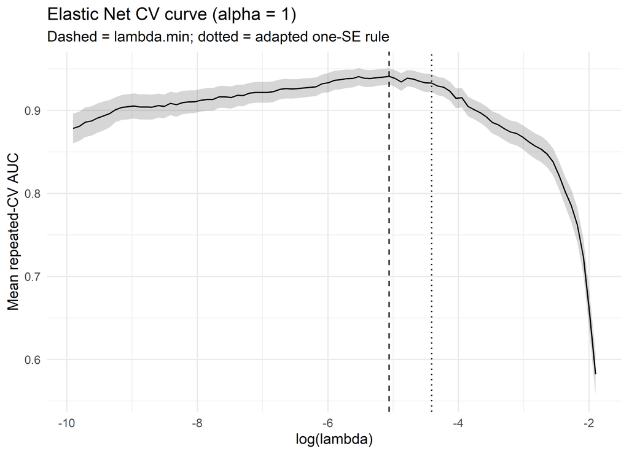

```r
cv_curve_df <- data.frame(
  log_lambda = log(best_result$lambda_seq),
  cv_auc = best_result$mean_auc,
  cv_auc_lo = best_result$mean_auc - best_result$se_auc,
  cv_auc_hi = best_result$mean_auc + best_result$se_auc
)

cv_plot <- ggplot(cv_curve_df, aes(log_lambda, cv_auc)) +
  geom_ribbon(aes(ymin = cv_auc_lo, ymax = cv_auc_hi), alpha = 0.2) +
  geom_line() +
  geom_vline(
    xintercept = log(best_result$lambda_min),
    linetype = "dashed"
  ) +
  geom_vline(
    xintercept = log(best_result$lambda_1se_adapted),
    linetype = "dotted"
  ) +
  labs(
    title = paste0("Elastic Net CV curve (alpha = ", best_alpha, ")"),
    subtitle = "Dashed = lambda.min; dotted = adapted one-SE rule",
    x = "log(lambda)", y = "Mean repeated-CV AUC"
  ) +
  theme_minimal(base_size = 12)

print(cv_plot)
```

```r
ggsave(
  file.path(figures_dir, "BinaryElasticNet_CV_Curve.png"),
  cv_plot, width = 8, height = 6, dpi = 300
)
```

# 9 Coefficients and Frozen Model

```r
coef_min <- as.matrix(
  coef(best_result$glmnet_fit, s = best_result$lambda_min)
)
coef_1se <- as.matrix(
  coef(best_result$glmnet_fit, s = best_result$lambda_1se_adapted)
)

build_coef_table <- function(coef_mat) {
  df <- data.frame(
    Feature = rownames(coef_mat),
    Estimate = as.numeric(coef_mat[, 1])
  )
  df <- df[df$Feature != "(Intercept)", , drop = FALSE]
  df$OddsRatio <- exp(df$Estimate)
  df$Nonzero <- df$Estimate != 0
  df[order(-abs(df$Estimate)), , drop = FALSE]
}

coef_table_min <- build_coef_table(coef_min)
coef_table_1se <- build_coef_table(coef_1se)

write.csv(
  coef_table_min,
  file.path(sens_results_dir, "BinaryElasticNet_Coefficients_LambdaMin.csv"),
  row.names = FALSE
)
write.csv(
  coef_table_1se,
  file.path(sens_results_dir, "BinaryElasticNet_Coefficients_Lambda1SE_Adapted.csv"),
  row.names = FALSE
)

elastic_net_model <- list(
  alpha = best_alpha,
  lambda_min = best_result$lambda_min,
  lambda_1se_adapted = best_result$lambda_1se_adapted,
  glmnet_fit = best_result$glmnet_fit,
  selected_features = selected_features,
  feature_names_used = colnames(x_train_mat),
  y_levels = levels(y_train),
  cv_auc_at_lambda_min = best_result$cv_auc_at_min,
  cv_se_at_lambda_min = best_result$cv_se_at_min
)

saveRDS(
  elastic_net_model,
  file.path(sens_models_dir, "BinaryElasticNet_Model.rds")
)
```

# 10 Metrics

```r
compute_metrics <- function(y_true, y_pred, prob_crc) {
  y_true <- factor(as.character(y_true), levels = c("healthy", "CRC"))
  y_pred <- factor(as.character(y_pred), levels = c("healthy", "CRC"))

  cm <- caret::confusionMatrix(
    y_pred, y_true, positive = "CRC"
  )

  roc_obj <- pROC::roc(
    response = y_true,
    predictor = as.numeric(prob_crc),
    levels = c("healthy", "CRC"),
    direction = "<",
    quiet = TRUE
  )

  mcc_val <- yardstick::mcc(
    data.frame(truth = y_true, prediction = y_pred),
    truth = truth, estimate = prediction
  )$.estimate

  list(
    metrics = data.frame(
      Accuracy = unname(cm$overall["Accuracy"]),
      Precision = unname(cm$byClass["Precision"]),
      Sensitivity = unname(cm$byClass["Sensitivity"]),
      Specificity = unname(cm$byClass["Specificity"]),
      F1 = unname(cm$byClass["F1"]),
      MCC = as.numeric(mcc_val),
      AUC = as.numeric(pROC::auc(roc_obj))
    ),
    cm = cm
  )
}

predict_elastic_net <- function(model, newx, lambda_val) {
  newx <- newx[, model$feature_names_used, drop = FALSE]

  prob_crc <- as.numeric(
    predict(
      model$glmnet_fit,
      newx = as.matrix(newx),
      s = lambda_val,
      type = "response"
    )
  )

  pred <- factor(
    ifelse(prob_crc >= 0.50, "CRC", "healthy"),
    levels = c("healthy", "CRC")
  )

  list(pred = pred, prob_crc = prob_crc)
}

# Stratified bootstrap: resample Healthy and CRC independently.
bootstrap_ci <- function(y_true, y_pred, prob_crc, B = 2000, seed = 123) {

  y_true <- factor(as.character(y_true), levels = c("healthy", "CRC"))
  y_pred <- factor(as.character(y_pred), levels = c("healthy", "CRC"))

  set.seed(seed)

  healthy_idx <- which(y_true == "healthy")
  crc_idx <- which(y_true == "CRC")

  boot <- vector("list", B)

  for (b in seq_len(B)) {
    idx <- c(
      sample(healthy_idx, length(healthy_idx), replace = TRUE),
      sample(crc_idx, length(crc_idx), replace = TRUE)
    )

    boot[[b]] <- compute_metrics(
      y_true[idx], y_pred[idx], prob_crc[idx]
    )$metrics[1, ]
  }

  boot_mat <- do.call(rbind, boot)

  ci <- t(apply(
    boot_mat, 2, quantile,
    probs = c(0.025, 0.975), na.rm = TRUE
  ))

  data.frame(
    Metric = rownames(ci),
    Lower_95_CI = ci[, 1],
    Upper_95_CI = ci[, 2],
    row.names = NULL
  )
}
```

# 11 Internal Held-Out Test

```r
pred_min <- predict_elastic_net(
  elastic_net_model, X_test_scaled, elastic_net_model$lambda_min
)

pred_1se <- predict_elastic_net(
  elastic_net_model, X_test_scaled, elastic_net_model$lambda_1se_adapted
)

metrics_min <- compute_metrics(y_test, pred_min$pred, pred_min$prob_crc)
metrics_1se <- compute_metrics(y_test, pred_1se$pred, pred_1se$prob_crc)

print(metrics_min$metrics)
```

```
##    Accuracy Precision Sensitivity Specificity        F1       MCC AUC
## 1 0.6818182 0.6666667         0.6        0.75 0.6315789 0.3544588 0.7
```

```r
print(metrics_1se$metrics)
```

```
##    Accuracy Precision Sensitivity Specificity        F1       MCC AUC
## 1 0.6818182 0.6666667         0.6        0.75 0.6315789 0.3544588 0.7
```

```r
save_predictions <- function(pred_obj, y_true, sample_ids, path) {
  df <- data.frame(
    SampleID = sample_ids,
    Actual = as.character(y_true),
    Predicted = as.character(pred_obj$pred),
    Probability_CRC = pred_obj$prob_crc,
    Probability_Healthy = 1 - pred_obj$prob_crc
  )
  write.csv(df, path, row.names = FALSE)
  df
}

internal_min_df <- save_predictions(
  pred_min, y_test, rownames(test_data),
  file.path(sens_results_dir, "BinaryElasticNet_InternalTest_Predictions_LambdaMin.csv")
)

internal_1se_df <- save_predictions(
  pred_1se, y_test, rownames(test_data),
  file.path(sens_results_dir, "BinaryElasticNet_InternalTest_Predictions_Lambda1SE_Adapted.csv")
)

set.seed(123)
internal_ci_min <- bootstrap_ci(
  y_test, pred_min$pred, pred_min$prob_crc, B = 2000, seed = 123
)
internal_ci_1se <- bootstrap_ci(
  y_test, pred_1se$pred, pred_1se$prob_crc, B = 2000, seed = 124
)

write.csv(
  internal_ci_min,
  file.path(sens_results_dir, "BinaryElasticNet_InternalTest_Bootstrap95CI_LambdaMin.csv"),
  row.names = FALSE
)
write.csv(
  internal_ci_1se,
  file.path(sens_results_dir, "BinaryElasticNet_InternalTest_Bootstrap95CI_Lambda1SE_Adapted.csv"),
  row.names = FALSE
)
```

# 12 External Validation

```r
load_external_cohort <- function(cohort_name) {
  obj <- curatedMetagenomicData(
    paste0(cohort_name, ".relative_abundance"), dryrun = FALSE
  )[[1]]

  list(
    X = as.data.frame(t(assay(obj))),
    y = colData(obj)$study_condition,
    sample_ids = colnames(obj),
    meta = colData(obj)
  )
}

prepare_external <- function(cohort_name) {
  loaded <- load_external_cohort(cohort_name)

  df <- loaded$X
  df$disease <- case_match(
    loaded$y, "control" ~ "healthy", .default = loaded$y
  )
  df$SampleID <- loaded$sample_ids

  df <- df[df$disease %in% c("healthy", "CRC"), , drop = FALSE]
  df$disease <- factor(df$disease, levels = c("healthy", "CRC"))

  list(
    data = df,
    meta = loaded$meta
  )
}

for (cohort_name in c("FengQ_2015", "VogtmannE_2016")) {

  cat("\n===== ", cohort_name, " =====\n", sep = "")

  cohort <- tryCatch(
    prepare_external(cohort_name),
    error = function(e) {
      warning("Could not load ", cohort_name, ": ", conditionMessage(e))
      NULL
    }
  )

  if (is.null(cohort)) next

  present <- selected_features %in% colnames(cohort$data)
  if (!all(present)) {
    stop(
      cohort_name, ": missing frozen features: ",
      paste(selected_features[!present], collapse = ", ")
    )
  }

  X_ext <- cohort$data[, selected_features, drop = FALSE]
  X_ext_scaled <- predict(scaler, X_ext)
  colnames(X_ext_scaled) <- make.names(colnames(X_ext_scaled))
  X_ext_scaled <- X_ext_scaled[, elastic_net_model$feature_names_used, drop = FALSE]

  p_min <- predict_elastic_net(
    elastic_net_model, X_ext_scaled, elastic_net_model$lambda_min
  )
  p_1se <- predict_elastic_net(
    elastic_net_model, X_ext_scaled, elastic_net_model$lambda_1se_adapted
  )

  m_min <- compute_metrics(
    cohort$data$disease, p_min$pred, p_min$prob_crc
  )
  m_1se <- compute_metrics(
    cohort$data$disease, p_1se$pred, p_1se$prob_crc
  )

  cohort_dir <- file.path(
    sens_results_dir, "external_validation", cohort_name
  )
  dir.create(cohort_dir, recursive = TRUE, showWarnings = FALSE)

  save_predictions(
    p_min, cohort$data$disease, cohort$data$SampleID,
    file.path(cohort_dir, "ElasticNet_LambdaMin_Predictions.csv")
  )
  save_predictions(
    p_1se, cohort$data$disease, cohort$data$SampleID,
    file.path(cohort_dir, "ElasticNet_Lambda1SE_Adapted_Predictions.csv")
  )

  write.csv(
    m_min$metrics,
    file.path(cohort_dir, "ElasticNet_LambdaMin_Metrics.csv"),
    row.names = FALSE
  )
  write.csv(
    m_1se$metrics,
    file.path(cohort_dir, "ElasticNet_Lambda1SE_Adapted_Metrics.csv"),
    row.names = FALSE
  )

  ci_min <- bootstrap_ci(
    cohort$data$disease, p_min$pred, p_min$prob_crc,
    B = 2000, seed = 2000
  )
  ci_1se <- bootstrap_ci(
    cohort$data$disease, p_1se$pred, p_1se$prob_crc,
    B = 2000, seed = 2001
  )

  write.csv(
    ci_min,
    file.path(cohort_dir, "ElasticNet_LambdaMin_Bootstrap95CI.csv"),
    row.names = FALSE
  )
  write.csv(
    ci_1se,
    file.path(cohort_dir, "ElasticNet_Lambda1SE_Adapted_Bootstrap95CI.csv"),
    row.names = FALSE
  )

  print(m_min$metrics)
  print(m_1se$metrics)
}
```

```
##
## ===== FengQ_2015 =====
##    Accuracy Precision Sensitivity Specificity        F1       MCC       AUC
## 1 0.7009346      0.85   0.3695652   0.9508197 0.5151515 0.4068565 0.7726301
##    Accuracy Precision Sensitivity Specificity        F1       MCC       AUC
## 1 0.7009346      0.85   0.3695652   0.9508197 0.5151515 0.4068565 0.7679971
##
## ===== VogtmannE_2016 =====
##    Accuracy Precision Sensitivity Specificity        F1       MCC       AUC
## 1 0.5673077       0.6   0.4038462   0.7307692 0.4827586 0.1424425 0.5906065
##    Accuracy Precision Sensitivity Specificity        F1       MCC       AUC
## 1 0.5673077 0.6206897   0.3461538   0.7884615 0.4444444 0.1500958 0.5880178
```

# 13 Forensic Self-Audit

```r
audit <- data.frame(
  Item = c(
    "Frozen 92/22 split reused",
    "Training labels 49 Healthy / 43 CRC",
    "Exactly 20 frozen microbial features",
    "No clinical metadata in predictors",
    "Scaler loaded and applied without refitting",
    "Frozen repeated-CV folds reused for tuning",
    "Alpha/lambda selected using training data only",
    "Fold-wise ROC AUC calculated from held-out probabilities",
    "No cv.glmnet AUC-to-deviance fallback used",
    "All tuning AUC values constrained to [0, 1]",
    "Internal test used only after tuning",
    "External cohorts evaluated without refitting",
    "Threshold fixed at 0.50",
    "AUC uses continuous CRC probability",
    "Bootstrap resamples fixed predictions within class",
    "B = 2000",
    "External model remains frozen",
    "Outputs isolated in sensitivity-analysis directory"
  ),
  Verified = c(
    nrow(train_data) == 92 && nrow(test_data) == 22,
    sum(y_train == "healthy") == 49 && sum(y_train == "CRC") == 43,
    ncol(X_train_scaled) == 20,
    length(intersect(
      c("disease","study_condition","age","gender","BMI","country"),
      colnames(X_train_scaled)
    )) == 0,
    TRUE,
    length(foldid_list) == 5 && all(foldid_audit$Unique_Folds == 10),
    all(vapply(alpha_tuning_results, function(r) {
      all(is.finite(r$mean_auc)) &&
        all(r$mean_auc >= 0 & r$mean_auc <= 1)
    }, logical(1))),
    TRUE,
    all(alpha_summary$CV_AUC_at_lambda_min >= 0 &
          alpha_summary$CV_AUC_at_lambda_min <= 1),
    TRUE,
    TRUE,
    TRUE,
    TRUE,
    TRUE,
    TRUE,
    TRUE,
    TRUE,
    dir.exists(sens_results_dir) && dir.exists(sens_models_dir)
  )
)

print(audit)
```

```
##                                                        Item Verified
## 1                                 Frozen 92/22 split reused     TRUE
## 2                       Training labels 49 Healthy / 43 CRC     TRUE
## 3                      Exactly 20 frozen microbial features     TRUE
## 4                        No clinical metadata in predictors     TRUE
## 5               Scaler loaded and applied without refitting     TRUE
## 6                Frozen repeated-CV folds reused for tuning     TRUE
## 7            Alpha/lambda selected using training data only     TRUE
## 8  Fold-wise ROC AUC calculated from held-out probabilities     TRUE
## 9                No cv.glmnet AUC-to-deviance fallback used     TRUE
## 10              All tuning AUC values constrained to [0, 1]     TRUE
## 11                     Internal test used only after tuning     TRUE
## 12             External cohorts evaluated without refitting     TRUE
## 13                                  Threshold fixed at 0.50     TRUE
## 14                      AUC uses continuous CRC probability     TRUE
## 15       Bootstrap resamples fixed predictions within class     TRUE
## 16                                                 B = 2000     TRUE
## 17                            External model remains frozen     TRUE
## 18       Outputs isolated in sensitivity-analysis directory     TRUE
```

```r
write.csv(
  audit,
  file.path(sens_results_dir, "BinaryElasticNet_ForensicAuditChecklist.csv"),
  row.names = FALSE
)

if (!all(audit$Verified)) {
  stop("Forensic audit failed. Inspect the checklist before using results.")
}
```

# 14 Session Information

```r
writeLines(
  file.path(sens_results_dir, "BinaryElasticNet_SessionInfo.txt")
)
```

[session information not shown]

## 14.1 Session information

The final section records the exact R session used for this knit. The same information is also saved as a text artifact so the HTML report and repository contain both a human-readable and machine-readable provenance record.

```r
session_file <- file.path(
  results_dir,
  "session_info",
  "05_Binary_LASSO_Sensitivity_sessionInfo.txt"
)
cat("Saved session information to:", session_file, "\n\n")
## Saved session information to: C:/CRC/CRC_Quantum_Microbiome_Githb/CRC_Quantum_Microbiome_GitHub_RMD/02 Classical ML/results/session_info/05_Binary_LASSO_Sensitivity_sessionInfo.txt
```

[session information not shown]